# R package development

Jae Yeon Kim

2021-03-08

> A data product is the production output from a statistical analysis. - [Brian Caffo](https://sites.google.com/view/bcaffo/home)

# Objectives

1. Reuse your code
2. Automate your workflow
3. Help others (be part of an open-source development community)

# Workflow

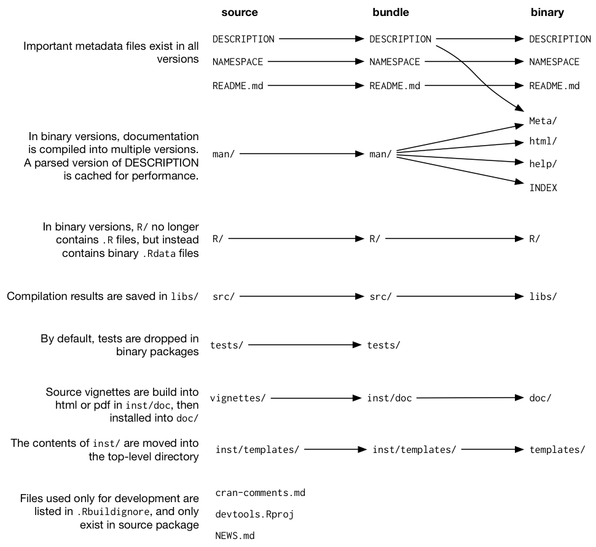

It’s time to learn five R code states: source, bundled, binary, installed, and in-memory.

If you’re using an R package, you’re only concerned of the last two states: `install.packages("pkg")` and `library(pkg)` If you’re developing an R package, you first write source code (`*.R`), bundle it (compressed file like `*.tar.gz`; done by `devtools::build()`), then make it binary (`devtools::build(binary = TRUE)`; This is how a package is stored in CRAN/GitHub, etc.).

# Required Components

The 4 required components are necessary to build and distribute a minimally viable R package. The other steps are optional.

- Package
  - `\R`: R functions
  - `\man`: function documentations
  - DESCRIPTION: provides meta data about the package (e.g., author)
  - LICENSE
    - GNU, MIT, etc.
  - NAMESPACE: package dependencies (to make your package self-contained)
  - README (optional)
1. Setup (**DESCRIPTION**)

I assume that you’ve already created and cloned a git repo. Move to your cloned repo file path in the file system.

```r
# This function creates DESCRIPTION file
usethis::create_package(here())

# License the package
# You can use the MIT license by typing devtools::use_mit_license("author name"). The function produces MIT license-related files (LICENSE, LICENSE.md).
use_mit_license("Jae Yeon Kim")

# Add news (optional)
# Helps track changes
use_news_md()
```

2. Write code (**R**)

If you want to turn your R markdown file into R script use `knitr::purl(input = “x.Rmd”, output = “x.R”). The [fusen package](https://thinkr-open.github.io/fusen/) helps to develop an R package based on R markdown files.

```r
usethis::use_r("rbind_mutate")
```

```r
#' Add two numbers
#'
#' @param x A number
#' @param y A number
#' @return The sum of x and y
#' @export

add <- function(x, y){

  x + y

}
```

If you used a function from other packages, you need to reference it in the following way: `#' @importFrom <package> <function>`

Many of us, use `%>%` operator. If you want to add this to your documentation, do `usethis::use_pipe()`.

3. Document (**man**)

This documentation is for the function manual.

```r
# Document
# The function creates documentation related files (NAMESPACE, function_name.rd)
devtools::document()

# Check; updates the documentation; builds and checks the package
devtools::check()
```

4. Organize (**NAMESPACE**)

This documentation is for [namespace](https://en.wikipedia.org/wiki/Namespace).

```r
usethis::use_package("dplyr")
```

# Optional Components

1. Test (**test**)

Although I said optional, automated unit testing is not option, when you’re writing a complex package. Testing will you save tons of time and energy.

- Setup

```r
usethis::use_testthat()

usethis::use_test("rbind_mutate")
```

- Testing

```r
# Make changes

# Load functions
devtools::load_all()

# Test
devtools::test()
```

2. Add data (**data**)

```r
x <- "Jae"
y <- "Sun"
z <- "Jane"

usethis::use_data(x, y, z, overwrite = TRUE)
```

3. Teach (**vignetts**)

```r
usethis::use_vignette("rbind_mutate")
```

```r
title: "Vignette title"
author: "Vignette author"
date: "2021-03-08"
output: rmarkdown::html_vignette
vignette: blah blah
```

- You can build a package website using `pkgdown`

```r
# install.packages("pkgdown")
usethis::use_pkgdown()
pkgdown::build_site()
```

- A package site includes information on METADATA, Function references, Articles, News, etc.

### Building an R package

- CMD (in the terminal)

You can run R commands in the terminal using R CMD.

- devtools

```r
# Build
devtools::build()

# Install
devtools::install()
```

# Distributing an R package

```r
# Version update
usethis::use_version()

# Spell check
usethis::use_spell_check()
```

1. [CRAN (The Comprehensive R Archive Network)](https://cran.r-project.org/)
- R package submission should comply with [the CRAN Repository Policy](https://cran.r-project.org/)
2. GitHub
- Push everything to the Git repository (you can do it using command-line interface or RStudio).
- Don’t forget that your repository should be `public`.
- I highly recommend connecting GitHub with SSH. For more information, visit [this link](https://docs.github.com/en/github/authenticating-to-github/connecting-to-github-with-ssh).

**Additional tips**

Sometimes, you get the following error: “Undefined global functions or variables” If you experience this problem, save the following script as `globals.r.`

```r
utils::globalVariables(c("<undefined variable name1>", "<undefined variable name2>", "<undefinedvariable name3"))
```

```
## [1] "<undefined variable name1>" "<undefined variable name2>"
## [3] "<undefinedvariable name3"
```